# Phonological gender marking in given names is a cross-linguistic regularity decoupled from societal gender equality

Thomas Schlatter

September 2026

# Abstract

Across the world’s languages, female and male given names tend to differ in sound: female names are widely reported to be longer, to end in vowels, and to favour sonorous, open articulations. Whether this pattern is a genuine cross-linguistic regularity, and whether its magnitude reflects how gender is organised in a society, remain open questions. Drawing on official government birth and population registries, this study quantifies the phonological female-male contrast in given names at scale. In a feature-level analysis spanning 112 registries, the direction of the contrast is near-invariant: female names carry a higher vowel proportion in 103 of 112 registries and a more sonorant profile in 104 of 112, while male names are more consonantal (105 of 112) and longer (81 of 112). A pooled multivariate model trained on the most frequent names from 107 registries separates female from male names with a count-weighted area under the curve of 0.799. Finally, in a broader sample of 53 countries, 47 of 53 show the female-male gap in the same direction (mean Cohen’s *d* = 0.54), yet the size of the gap is unrelated to a standard index of national gender parity (*r* = +.075, *p* = .595). Phonological gender marking in names thus emerges as a robust linguistic regularity that is statistically decoupled from societal gender equality, consistent with a sound-symbolic rather than a sociopolitical account of its origin.

# Introduction

That names sound gendered is a familiar intuition, and a measurable one. English *Emma*, *Sophia*, and *Olivia* end in open vowels and string together sonorant consonants; *Brett*, *Mark*, and *Kurt* are short, closed, and obstruent-heavy. Early quantitative work established that such regularities are not idiosyncratic to English. Female names are, on average, longer, more likely to be stressed on a non-initial syllable, more likely to end in a vowel, and more likely to contain the acoustically diffuse, high-sonority segments that the broader sound-symbolism literature associates with smallness and softness (Cutler, McQueen, & Robinson, 1990; Slater & Feinman, 1985; Wright, Hay, & Bent, 2005; Pitcher, Mesoudi, & McElligott, 2013). Listeners exploit these cues: novel names and nonwords are reliably sex-typed from form alone, and the effect aligns with the same sound-meaning mappings that drive the *bouba-kiki* phenomenon (Sidhu & Pexman, 2018; Sidhu, Pexman, & Saint-Aubin, 2019).

Two questions have proven harder to settle. The first is universality. Most evidence comes from a handful of well-studied European languages, and the convenience samples that dominate the literature (telephone directories, single-cohort birth lists, online name corpora) make it difficult to know whether the female-male contrast is a property of naming in general or an areal feature of the Indo-European naming tradition. The second question concerns explanation. If female names really are softer and more sonorous across cultures, is that contrast a reflex of how those cultures construct gender, sharpening where gender roles are most differentiated and flattening where they are most equal? Or is it a sound-symbolic regularity that operates below the level of deliberate social choice, and therefore largely indifferent to a society’s gender politics? These two readings make opposite predictions about the relationship between the phonological gap and societal measures of gender equality.

Answering either question requires moving beyond convenience samples to the populations that actually bear names. National civil registries, the administrative records of births and resident populations, provide exactly this: frequency-weighted name distributions for entire countries, in dozens of languages and writing systems. The present study assembles such registries at scale and uses grapheme-to-phoneme conversion to place every name in a common phonological feature space. Three analyses follow. Analysis 1 asks how consistent the direction of the female-male contrast is, feature by feature, across registries. Analysis 2 asks how strongly the contrast separates the sexes when phonological features are combined multivariately. Analysis 3 turns to the explanatory question, testing whether the size of the contrast tracks a standard index of national gender equality across a broad country sample.

# Data and Methods

## Name registries

Names were drawn from official government birth and population registries (national statistical offices, civil registration authorities, and equivalent bodies). Each source provides given names with a sex label and a frequency (annual births or resident counts). Where a registry reported names by year, counts were summed within name and sex. Analyses weight by these frequencies, so that common names contribute in proportion to the people who carry them rather than appearing as single types.

## Phonological transcription

Names were converted to the International Phonetic Alphabet with a source-aware grapheme-to-phoneme pipeline. Most languages were transcribed with eSpeak NG using the language-appropriate voice; Mandarin names were routed through pinyin before conversion, and a small number of orthographically transparent inventories used dedicated segmental rules. Because grapheme-to-phoneme conversion is language-specific, each registry was assigned its language explicitly rather than detected automatically.

One class of script was excluded by design. Hebrew and Arabic are written as abjads, omitting short vowels, so transcription of the unvocalised registry text returns consonant skeletons (for example, Hebrew *Adam* renders as a vowelless /ʔdm/) that would systematically deflate exactly the vowel and sonority features under study. These sources were removed rather than retained, because the distortion is silent and cannot be detected by the artifact screens used for other languages. Transcriptions flagged as language-switching or spelled-out artifacts (for instance, an East Asian source whose logographic names fall back to a literal gloss) were filtered, and any source exceeding a 25% weighted artifact rate was dropped in full.

## Phonological features and effect sizes

Each transcription was mapped to articulatory features using the panphon feature system. For every name, feature values were averaged across its segments, yielding a name-level profile (the proportion of segments that are sonorant, vocalic, consonantal, and so on), together with name length in segments. The female-male contrast on a given feature within a registry is summarised as a frequency-weighted Cohen’s *d* (female minus male), with pooled within-sex variance. A positive *d* indicates a higher value among female names.

## Societal gender equality

For the cross-cultural analysis, the per-country phonological gap was paired with a standard composite index of national gender parity (higher values denote greater equality). This broader country panel draws on a wider, partly non-registry name sample and is therefore treated as a secondary, exploratory tier; the registry-based universality results in Analyses 1 and 2 do not depend on it.

# Analysis 1: How consistent is the female-male contrast?

The first question is directional: for each phonological feature, does the female-male contrast point the same way across registries? Table 1 summarises the 112-registry tally for the features that most clearly distinguish the sexes.

Table 1. Direction of the female-male phonological contrast across 112 official name registries.

| Feature | Higher in | Registries agreeing | % agreeing | Mean F - M |
| --- | --- | --- | --- | --- |
| Vowel proportion | Female | 103 / 112 | 92% | +0.065 |
| Syllabic | Female | 103 / 112 | 92% | +0.065 |
| Sonorant | Female | 104 / 112 | 93% | +0.076 |
| Continuant | Female | 103 / 112 | 92% | +0.075 |
| Voiced | Female | 96 / 112 | 86% | +0.057 |
| Consonantal | Male | 105 / 112 | 94% | -0.072 |
| Rounded | Male | 105 / 112 | 94% | -0.058 |
| Name length | Male | 81 / 112 | 72% | -0.267 |

The pattern is strikingly consistent. The single most reliable cue is vocalic openness: female names carry a higher proportion of vowels in 103 of 112 registries, a contrast that reverses in only 9. Sonority behaves almost identically, with female names more sonorant in 104 of 112 registries. The complementary consonantal dimensions point the other way with comparable regularity: male names are more consonantal in 105 of 112 registries and longer in 81. In other words, the female-male contrast is not a property of one or two languages that happens to recur; it is the default direction of phonological gender marking wherever names are recorded, holding across the writing systems and language families represented in the registry set.

# Analysis 2: How strongly do the features combine?

Directional consistency does not by itself establish that the cues are individually large; each per-feature gap is modest (Table 1). The relevant question for sex-typing is whether the cues combine into a discriminable signal. To test this, a count-weighted logistic regression predicted name sex from the full set of phonological features, with registry fixed effects to absorb between-language baseline differences, fitted to the most frequent names (top 30 per sex) from 107 registries (*N* = 5,560 weighted name types).

Table 2. Strongest phonological predictors of name sex in the pooled multivariate model.

| Feature | Standardised coefficient | Predicts |
| --- | --- | --- |
| sonorant | -1.21 | Female |
| strident | -0.81 | Female |
| nasal | +0.75 | Male |
| rounded | +0.71 | Male |
| consonantal | +0.43 | Male |
| continuant | +0.40 | Male |
| open (low) vowels | -0.33 | Female |
| coronal | -0.27 | Female |

Combined, the features separate female from male names with a count-weighted area under the ROC curve of 0.799 and a weighted accuracy of 73.3%. The multivariate profile recapitulates the single-feature picture: openness and sonority pull strongly toward the female pole, while consonantality and back, rounded vowel quality pull toward the male pole. The discriminating signal is therefore not carried by any one cue but distributed across the same vocalic and sonorant dimensions that proved most consistent in Analysis 1.

# Analysis 3: Does the contrast track gender equality?

If the phonological female-male contrast were a reflex of socially constructed gender roles, its magnitude should covary with how unequally a society treats women and men: larger where gender is sharply differentiated, smaller where it is not. Analysis 3 tests this across a broader panel of 53 countries, relating each country’s phonological gap (Cohen’s *d*) to a standard national gender-equality index.

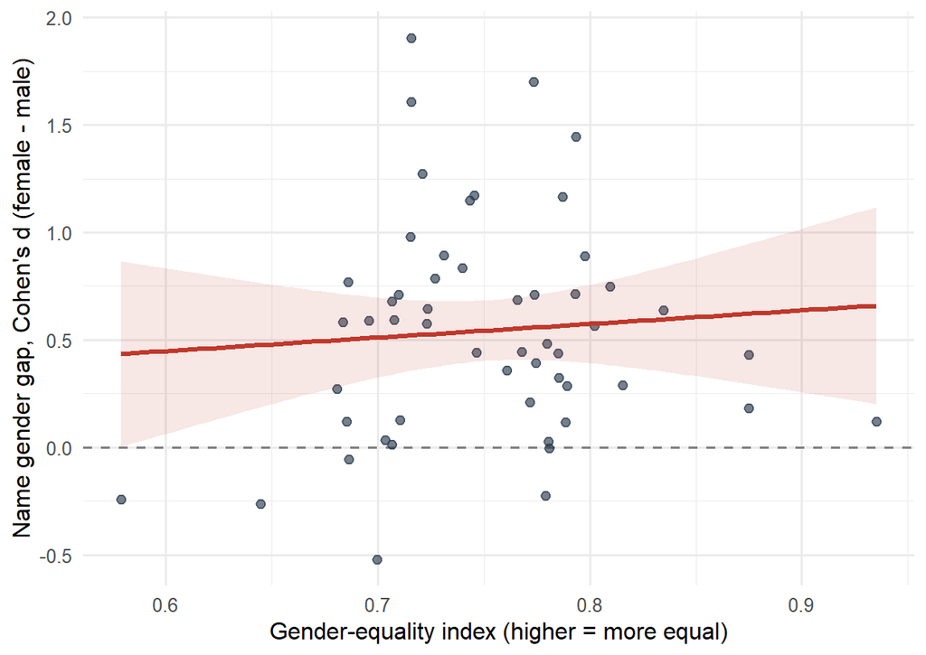

Figure 1. National name gender gap (Cohen’s d) against the gender-equality index, 53 countries. The dashed line marks d = 0 (no gap). 47 of 53 countries lie above it; the slope with gender equality is flat and non-significant.

# Discussion

Three results converge. The female-male phonological contrast in given names is near-invariant in direction across 112 registries (Analysis 1), combines into a strongly discriminable multivariate signal (Analysis 2), and holds in 47 of 53 countries sampled, yet its magnitude does not move with societal gender equality (Analysis 3). Taken together they favour a particular reading: phonological gender marking in names is a robust linguistic regularity that operates largely below the level of deliberate social negotiation.

The decoupling from gender equality is the most informative of the three. A socio-structural account, on which gendered name forms encode and reproduce a society’s gender hierarchy, predicts that the contrast should attenuate as that hierarchy flattens. It does not. The gap in the most gender-equal countries is indistinguishable from the gap in the least equal. What this argues against is a strong attributional claim, that the sound of gendered names is a direct expression of unequal gender relations. What it argues for is a sound-symbolic account in which the contrast is anchored in stable form-meaning associations. The features that carry the contrast, vocalic openness and sonority on the female side and consonantal closure and length on the male side, are precisely those that the frequency code links to body size and the bouba-kiki literature links to softness versus angularity (Ohala, 1994; Sidhu & Pexman, 2018). On this view, naming traditions recruit a pre-existing perceptual mapping, and they do so to a similar degree regardless of how the surrounding society organises gender.

This conclusion sits comfortably alongside, and helps interpret, the broader finding that gendered evaluative and grammatical patterns in language are often weakly tied to measured gender attitudes. It also reframes the female-male name contrast as a phenomenon for the psychology of sound symbolism rather than primarily a marker of social inequality, a distinction with practical as well as theoretical consequences for how such patterns are described.

## Limitations

# Conclusion

Female and male given names differ in sound in the same way almost everywhere: female names are more open and sonorous, male names more consonantal and longer. The contrast is consistent across 112 official registries, discriminates the sexes with an area under the curve near 0.80, and appears in 47 of the 53 countries examined, yet it does not grow or shrink with societal gender equality. Phonological gender marking in names is best understood not as an echo of social inequality but as a cross-linguistic sound-symbolic regularity that naming traditions inherit in common.

# References

Cutler, A., McQueen, J., & Robinson, K. (1990). Elizabeth and John: Sound patterns of men’s and women’s names. *Journal of Linguistics, 26*(2), 471-482.

Ohala, J. J. (1994). The frequency code underlies the sound-symbolic use of voice pitch. In L. Hinton, J. Nichols, & J. J. Ohala (Eds.), *Sound symbolism* (pp. 325-347). Cambridge University Press.

Pitcher, B. J., Mesoudi, A., & McElligott, A. G. (2013). Sex-biased sound symbolism in English-language first names. *PLOS ONE, 8*(6), e64825.

Sidhu, D. M., & Pexman, P. M. (2018). Five mechanisms of sound symbolic association. *Psychonomic Bulletin & Review, 25*(5), 1619-1643.

Sidhu, D. M., Pexman, P. M., & Saint-Aubin, J. (2019). Is more sound symbolism better than less? *Cognition, 188*, 100-104.

Slater, A. S., & Feinman, S. (1985). Gender and the phonology of North American first names. *Sex Roles, 13*(7-8), 429-440.

Wright, S. K., Hay, J., & Bent, T. (2005). Ladies first? Phonology, frequency, and the naming conspiracy. *Linguistics, 43*(3), 531-561.